# Time Value of Money

# Review

- Look for shapes constant, geometric gradient and linear gradient.
- Count for the N. Remember to add one for the pot *only* on linear gradient.
- Sum of N and exponent is equal to the time period where you last see the cash flow
- Work the analogy with slope intercept form of a line.

# Big Test

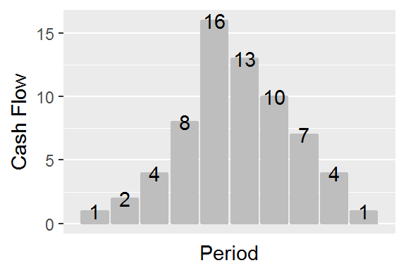

# Big Test ( A Solution)

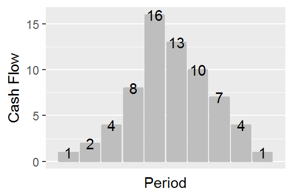

$$\frac{1(P|A_1, i, g = 100\%, 4)}{(1+i)^{-1}} + \frac{16 (P|A, i, 6)}{(1+i)^3} - \frac{3 (P|G, i, 6)}{(1+i)^3}$$

# Similar problem

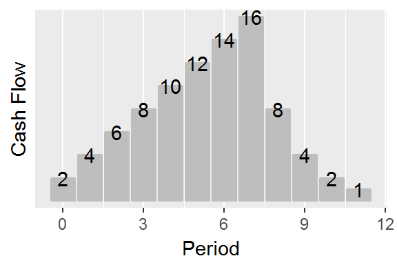

# Similar problem (Solution)

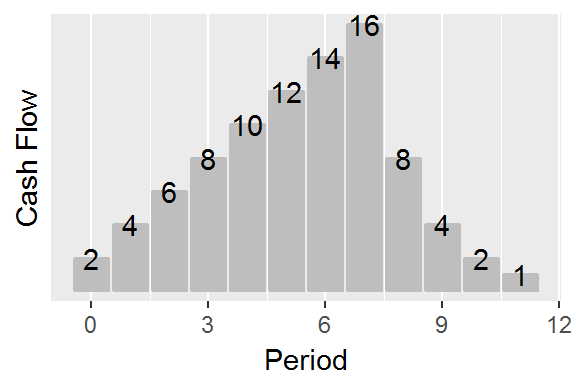

# Lets go backwards. Find the intended cash flow for this.

$$\frac{5(P|A, i, 10)}{(1+i)^2} - \frac{1 (P|G, i, 4)}{ (1+i)^ 4}$$

# Solution

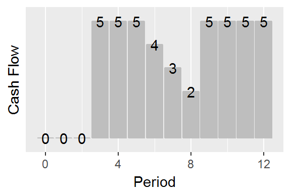

# Hints for Study

- Kill trees. Work lots of problems. Everything after this depends on understanding TVM.
- Drill and Kill the examples and the videos at bottom of the page. http://ec314-pdx-edu.wikidot.com/q2:time-value-of-money
- When evaluating these expressions, try to do all the work in the calculator in one operation. Sometimes rounding and truncation errors are bad with large interest rates.
- Go forwards, factor notation to cash flow diagram, and backwards, cash flow to factor.